# Project: Identify Customer Segments

In this project, you will apply unsupervised learning techniques to identify segments of the population that form the core customer base for a mail-order sales company in Germany. These segments can then be used to direct marketing campaigns towards audiences that will have the highest expected rate of returns. The data that you will use has been provided by our partners at Bertelsmann Arvato Analytics, and represents a real-life data science task.

This notebook will help you complete this task by providing a framework within which you will perform your analysis steps. In each step of the project, you will see some text describing the subtask that you will perform, followed by one or more code cells for you to complete your work. **Feel free to add additional code and markdown cells as you go along so that you can explore everything in precise chunks.** The code cells provided in the base template will outline only the major tasks, and will usually not be enough to cover all of the minor tasks that comprise it.

It should be noted that while there will be precise guidelines on how you should handle certain tasks in the project, there will also be places where an exact specification is not provided. **There will be times in the project where you will need to make and justify your own decisions on how to treat the data.** These are places where there may not be only one way to handle the data. In real-life tasks, there may be many valid ways to approach an analysis task. One of the most important things you can do is clearly document your approach so that other scientists can understand the decisions you've made.

At the end of most sections, there will be a Markdown cell labeled **Discussion**. In these cells, you will report your findings for the completed section, as well as document the decisions that you made in your approach to each subtask. **Your project will be evaluated not just on the code used to complete the tasks outlined, but also your communication about your observations and conclusions at each stage.**

## Project Overview

In this project, unsupervised learning techniques are used to identify customer segments from demographic data of the general population in Germany and compare them with segments from a mail-order company’s customers.

The objective is to determine which population segments are over- or under-represented among customers, enabling more targeted marketing strategies.

## Approach Overview

This project follows a structured pipeline:

- Data cleaning and feature engineering
- Dimensionality reduction using PCA
- Clustering using KMeans
- Segment interpretation and comparison with customer data

This approach transforms high-dimensional demographic data into interpretable customer segments that support targeted marketing decisions.

Each section includes:

- Data Analysis - Inspecting and reasoning
- Helper Function(s) - Reusable transformations
- Cleaning/Transformation - Applicatiion of steps
- Discussion - Observations and interpretations

```python
# import libraries here; add more as necessary
import numpy as np
import pandas as pd
import matplotlib.pyplot as plt
import seaborn as sns
import ast

from sklearn.cluster import KMeans
from sklearn.decomposition import PCA
from sklearn.impute import SimpleImputer
from sklearn.metrics import silhouette_score
from sklearn.preprocessing import OneHotEncoder, StandardScaler

# magic word for producing visualizations in notebook
%matplotlib inline

pd.options.display.max_rows = None
pd.options.display.max_columns = None
```

### Step 0: Load the Data

There are four files associated with this project (not including this one):

- `Udacity_AZDIAS_Subset.csv`: Demographics data for the general population of Germany; 891211 persons (rows) x 85 features (columns).
- `Udacity_CUSTOMERS_Subset.csv`: Demographics data for customers of a mail-order company; 191652 persons (rows) x 85 features (columns).
- `Data_Dictionary.md`: Detailed information file about the features in the provided datasets.
- `AZDIAS_Feature_Summary.csv`: Summary of feature attributes for demographics data; 85 features (rows) x 4 columns

Each row of the demographics files represents a single person, but also includes information outside of individuals, including information about their household, building, and neighborhood. You will use this information to cluster the general population into groups with similar demographic properties. Then, you will see how the people in the customers dataset fit into those created clusters. The hope here is that certain clusters are over-represented in the customers data, as compared to the general population; those over-represented clusters will be assumed to be part of the core userbase. This information can then be used for further applications, such as targeting for a marketing campaign.

To start off with, load in the demographics data for the general population into a pandas DataFrame, and do the same for the feature attributes summary. Note for all of the `.csv` data files in this project: they're semicolon (`;`) delimited, so you'll need an additional argument in your [`read_csv()`](https://pandas.pydata.org/pandas-docs/stable/generated/pandas.read_csv.html) call to read in the data properly. Also, considering the size of the main dataset, it may take some time for it to load completely.

Once the dataset is loaded, it's recommended that you take a little bit of time just browsing the general structure of the dataset and feature summary file. You'll be getting deep into the innards of the cleaning in the first major step of the project, so gaining some general familiarity can help you get your bearings.

```python
# Debugging and logging
debug_enabled = False

def print_debug_info(message):
    if debug_enabled == True:
        print(message)
```

```python
# Load in the general demographics data.
df_demographics = pd.read_csv("Udacity_AZDIAS_Subset.csv", sep = ";")

# Load in the feature summary file.
df_feature_summary = pd.read_csv("AZDIAS_Feature_Summary.csv", sep = ";")
```

```python
# Check the structure of the data after it's loaded (e.g. print the number of
# rows and columns, print the first few rows).

# Check dataset dimensions
print(f"Demographics shape: {df_demographics.shape}")
print(f"Feature summary shape: {df_feature_summary.shape}")

# Preview demographics data
df_demographics.head()
```

```
Demographics shape: (891221, 85)
Feature summary shape: (85, 4)
```

|  | AGER_TYP | ALTERSKATEGORIE_GROB | ANREDE_KZ | CJT_GESAMTTYP | FINANZ_MINIMALIST | FINANZ_SPARER | FINANZ_VORSORGER | FINANZ_ANLEGER | FINANZ_UNAUFFAELLIGER | FINANZ_HAUSBAUER | FINANZTYP | GEBURTSJAHR | GFK_URLAUBERTYP | GREEN_AVANTGARDE | HEALTH_TYP | LP_LEBENSPHASE_FEIN | LP_LEBENSPHASE_GROB | LP_FAMILIE_FEIN | LP_FAMILIE_GROB | LP_STATUS_FEIN | LP_STATUS_GROB | NATIONALITAET_KZ | PRAEGENDE_JUGENDJAHRE | RETOURTYP_BK_S | SEMIO_SOZ | SEMIO_FAM | SEMIO_REL | SEMIO_MAT | SEMIO_VERT | … |
| --- | --- | --- | --- | --- | --- | --- | --- | --- | --- | --- | --- | --- | --- | --- | --- | --- | --- | --- | --- | --- | --- | --- | --- | --- | --- | --- | --- | --- | --- | --- |
| 0 | -1 | 2 | 1 | 2.0 | 3 | 4 | 3 | 5 | 5 | 3 | 4 | 0 | 10.0 | 0 | -1 | 15.0 | 4.0 | 2.0 | 2.0 | 1.0 | 1.0 | 0 | 0 | 5.0 | 2 | 6 | 7 | 5 | 1 | … |
| 1 | -1 | 1 | 2 | 5.0 | 1 | 5 | 2 | 5 | 4 | 5 | 1 | 1996 | 10.0 | 0 | 3 | 21.0 | 6.0 | 5.0 | 3.0 | 2.0 | 1.0 | 1 | 14 | 1.0 | 5 | 4 | 4 | 3 | 1 | … |
| 2 | -1 | 3 | 2 | 3.0 | 1 | 4 | 1 | 2 | 3 | 5 | 1 | 1979 | 10.0 | 1 | 3 | 3.0 | 1.0 | 1.0 | 1.0 | 3.0 | 2.0 | 1 | 15 | 3.0 | 4 | 1 | 3 | 3 | 4 | … |
| 3 | 2 | 4 | 2 | 2.0 | 4 | 2 | 5 | 2 | 1 | 2 | 6 | 1957 | 1.0 | 0 | 2 | 0.0 | 0.0 | 0.0 | 0.0 | 9.0 | 4.0 | 1 | 8 | 2.0 | 5 | 1 | 2 | 1 | 4 | … |
| 4 | -1 | 3 | 1 | 5.0 | 4 | 3 | 4 | 1 | 3 | 2 | 5 | 1963 | 5.0 | 0 | 3 | 32.0 | 10.0 | 10.0 | 5.0 | 3.0 | 2.0 | 1 | 8 | 5.0 | 6 | 4 | 4 | 2 | 7 | … |

```python
# Preview feature summary data
df_feature_summary.head()
```

|  | attribute | information_level | type | missing_or_unknown |
| --- | --- | --- | --- | --- |
| 0 | AGER_TYP | person | categorical | [-1,0] |
| 1 | ALTERSKATEGORIE_GROB | person | ordinal | [-1,0,9] |
| 2 | ANREDE_KZ | person | categorical | [-1,0] |
| 3 | CJT_GESAMTTYP | person | categorical | [0] |
| 4 | FINANZ_MINIMALIST | person | ordinal | [-1] |

## Data Dictionary Review

A manual review of the data dictionary was conducted to understand feature meanings and their relevance to the analysis.

Based on this review:

- Features were grouped into high-level categories
- Initial decisions were made on whether to keep, drop, or transform features
- These decisions were refined further during code-based analysis later in the notebook

A detailed log of feature-level decisions is maintained separately in the **Customer Segmentation - Feature Decisions Log**.

### Feature Categories

- Behavior
- Demographics
- Financial
- Geography
- Household
- Housing
- Life Stage
- Personality
- Wealth

### Initial Feature Selection Hypothesis

Based on the data dictionary review, an initial hypothesis was formed regarding which features to keep, drop, or transform.

These decisions are preliminary and will be validated and refined through data-driven analysis in the following steps.

These groupings will guide the preprocessing steps, particularly in handling missing values, feature transformation, and dimensionality reduction.

```python
# Feature groups based on initial hypothesis (to be validated during preprocessing)

keep_features = ["CJT_GESAMTTYP", "GFK_URLAUBERTYP", "GREEN_AVANTGARDE", "RETOURTYP_BK_S", "SHOPPER_TYP","ZABEOTYP",
                 "ONLINE_AFFINITAET", "ANZ_HAUSHALTE_AKTIV", "GEBAEUDETYP", "KONSUMNAEHE", "OST_WEST_KZ", "ALTERSKATEGORIE_GROB",
                 "FINANZ_MINIMALIST", "FINANZ_SPARER", "FINANZ_VORSORGER", "FINANZ_ANLEGER", "FINANZ_UNAUFFAELLIGER", "FINANZ_HAUSBAUER",
                 "BALLRAUM", "EWDICHTE", "KKK", "ORTSGR_KLS9", "RELAT_AB", "ANZ_PERSONEN", "HH_EINKOMMEN_SCORE", "KK_KUNDENTYP",
                 "W_KEIT_KIND_HH", "WOHNDAUER_2008", "KBA05_ANTG1", "KBA05_ANTG3", "KBA13_ANZAHL_PKW", "PLZ8_ANTG1", "PLZ8_ANTG3",
                 "PLZ8_HHZ", "LP_LEBENSPHASE_GROB", "LP_FAMILIE_GROB", "LP_STATUS_GROB", "SEMIO_SOZ", "SEMIO_FAM", "SEMIO_MAT",
                 "SEMIO_LUST", "SEMIO_ERL", "SEMIO_RAT", "VERS_TYP", "SOHO_KZ", "INNENSTADT", "GEBAEUDETYP_RASTER", "MOBI_REGIO",
                 "REGIOTYP", "ARBEIT", "KBA05_GBZ", "PLZ8_BAUMAX", "PLZ8_GBZ", "SEMIO_KRIT"]

drop_features = ["ANZ_HH_TITEL", "AGER_TYP", "TITEL_KZ", "ANZ_TITEL", "KBA05_ANTG2", "KBA05_ANTG4", "KBA05_BAUMAX", "PLZ8_ANTG2",
                 "PLZ8_ANTG4", "LP_LEBENSPHASE_FEIN", "LP_FAMILIE_FEIN", "LP_STATUS_FEIN", "ANREDE_KZ", "NATIONALITAET_KZ", "HEALTH_TYP",
                 "SEMIO_REL", "SEMIO_VERT", "SEMIO_KAEM", "CAMEO_DEUG_2015", "FINANZTYP", "SEMIO_KULT","SEMIO_DOM","SEMIO_PFLICHT",
                 "SEMIO_TRADV"]

transform_features = ["PRAEGENDE_JUGENDJAHRE", "WOHNLAGE", "GEBURTSJAHR", "ALTER_HH", "CAMEO_DEU_2015","CAMEO_INTL_2015",
                      "MIN_GEBAEUDEJAHR"]

print(f"Keep features: {len(keep_features)}")
print(f"Drop features: {len(drop_features)}")
print(f"Transform features: {len(transform_features)}")
```

```
Keep features: 54
Drop features: 24
Transform features: 7
```

> **Tip**: Add additional cells to keep everything in reasonably-sized chunks! Keyboard shortcut `esc --> a` (press escape to enter command mode, then press the 'A' key) adds a new cell before the active cell, and `esc --> b` adds a new cell after the active cell. If you need to convert an active cell to a markdown cell, use `esc --> m` and to convert to a code cell, use `esc --> y`.

## Step 1: Preprocessing

### Step 1.1: Assess Missing Data

The feature summary file contains a summary of properties for each demographics data column. You will use this file to help you make cleaning decisions during this stage of the project. First of all, you should assess the demographics data in terms of missing data. Pay attention to the following points as you perform your analysis, and take notes on what you observe. Make sure that you fill in the **Discussion** cell with your findings and decisions at the end of each step that has one!

#### Step 1.1.1: Convert Missing Value Codes to NaNs

The fourth column of the feature attributes summary (loaded in above as `feat_info`) documents the codes from the data dictionary that indicate missing or unknown data. While the file encodes this as a list (e.g. `[-1,0]`), this will get read in as a string object. You'll need to do a little bit of parsing to make use of it to identify and clean the data. Convert data that matches a 'missing' or 'unknown' value code into a numpy NaN value. You might want to see how much data takes on a 'missing' or 'unknown' code, and how much data is naturally missing, as a point of interest.

**As one more reminder, you are encouraged to add additional cells to break up your analysis into manageable chunks.**

**Data Analysis**

```python
missing_by_col = df_demographics.isnull().sum().sort_values(ascending=False)
missing_by_col.head(20)
```

```
KK_KUNDENTYP        584612
KBA05_GBZ           133324
KBA05_ANTG1         133324
KBA05_ANTG3         133324
MOBI_REGIO          133324
KBA05_ANTG2         133324
KBA05_ANTG4         133324
KBA05_BAUMAX        133324
REGIOTYP            121196
KKK                 121196
PLZ8_HHZ            116515
PLZ8_BAUMAX         116515
PLZ8_ANTG4          116515
PLZ8_GBZ            116515
PLZ8_ANTG2          116515
PLZ8_ANTG1          116515
PLZ8_ANTG3          116515
W_KEIT_KIND_HH      107602
KBA13_ANZAHL_PKW    105800
CAMEO_INTL_2015      98979
dtype: int64
```

```python
missing_per_row = df_demographics.isnull().sum(axis=1)
missing_per_row.describe()
```

```
count    891221.000000
mean          5.494527
std          12.271097
min           0.000000
25%           0.000000
50%           1.000000
75%           1.000000
max          46.000000
dtype: float64
```

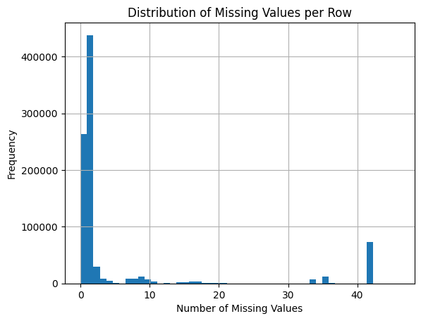

```python
missing_per_row.hist(bins=50)
plt.title("Distribution of Missing Values per Row")
plt.xlabel("Number of Missing Values")
plt.ylabel("Frequency")
plt.savefig("images/missing_val_dist-by_row.png", bbox_inches="tight")
plt.show()
```

**Helper Function(s)**

```python
def parse_missing_values(val):
    if pd.isna(val) or val == "[]":
        return []

    # To handle cases such as [-1,X], need to look at each element
    value = str(val).strip().strip("[]").strip()

    if not value:
        return []

    values = [s.strip() for s in value.split(",")]

    parsed = []

    for v in values:
        if v in {"X","XX"}:
            parsed.append(v)
        else:
            try:
                parsed.append(int(v))
            except ValueError:
                parsed.append(v)

    return parsed

# Test parse_missing_values
if debug_enabled == True:
    print(f"[] returned {parse_missing_values('[]')}")
    print(f"[1] returned {parse_missing_values('[1]')}")
    print(f"[1,-1] returned {parse_missing_values('[1,-1]')}")
    print(f"[XX] returned {parse_missing_values('[XX]')}")
    print(f"[-1,X] returned {parse_missing_values('[-1,X]')}")
```

```python
def standardize_missing_values(df, df_feature_summary):

    df_copy = df.copy()

    df_feature_summary_copy = df_feature_summary.copy()
    df_feature_summary_copy["missing_parsed"] = df_feature_summary_copy["missing_or_unknown"].apply(parse_missing_values)

    missing_values_map = {}

    for _, row in df_feature_summary_copy.iterrows():
        col = row["attribute"]
        vals = row["missing_parsed"]

        if not vals:
            continue

        missing_values_map[col] = vals

    for col, vals in missing_values_map.items():
        if col in df_copy.columns:
            df_copy[col] = df_copy[col].replace(vals, np.nan)

    return df_copy
```

**Cleaning/Transformation**

```python
# Identify missing or unknown data values and convert them to NaNs.
df_demographics = standardize_missing_values(df_demographics, df_feature_summary)
```

```python
df_demographics.isnull().sum().head()
```

```
AGER_TYP                685843
ALTERSKATEGORIE_GROB      2881
ANREDE_KZ                    0
CJT_GESAMTTYP             4854
FINANZ_MINIMALIST            0
dtype: int64
```

The encoded missing values have been successfully converted to NaN, enabling consistent handling of missing data in subsequent steps.

**Discussion**

Missing values in the dataset are encoded using dataset-specific placeholders such as `-1`, `0`, `X`, and `XX`, as indicated in the feature summary dataset. These values are not initially represented as standard missing values (`NaN`) and therefore require explicit conversion during the data cleaning step.

*Missing Values by Column*

An analysis of missing values by column shows that several features, particularly those related to microcell and regional attributes (e.g., KBA05_* and PLZ8_*), contain a significant number of missing values. This suggests that missingness is not random but rather dependent on geographic or structural factors.

*Missing Values by Row*

Analysis of missing values per row reveals that most rows contain very few missing values:

- Median missing values per row: 1
- 75th percentile: 1
- Mean: ~5.5
- Maximum: 46

This indicates that while most observations are largely complete, a small subset of rows contains a high number of missing values.

*Conclusion*

Given that missing values are encoded using special placeholders and that most rows contain minimal missing data, proceed by standardizing these placeholders into `NaN` during the cleaning stage and applying imputation rather than removing large portions of the dataset.

#### Step 1.1.2: Assess Missing Data in Each Column

How much missing data is present in each column? There are a few columns that are outliers in terms of the proportion of values that are missing. You will want to use matplotlib's [`hist()`](https://matplotlib.org/api/_as_gen/matplotlib.pyplot.hist.html) function to visualize the distribution of missing value counts to find these columns. Identify and document these columns. While some of these columns might have justifications for keeping or re-encoding the data, for this project you should just remove them from the dataframe. (Feel free to make remarks about these outlier columns in the discussion, however!)

For the remaining features, are there any patterns in which columns have, or share, missing data?

**Data Analysis**

```python
# Perform an assessment of how much missing data there is in each column of the
# dataset.
missing_percent = df_demographics.isnull().mean()*100
missing_percent.sort_values(ascending=False).head(10)
```

```
TITEL_KZ          99.757636
AGER_TYP          76.955435
KK_KUNDENTYP      65.596749
KBA05_BAUMAX      53.468668
GEBURTSJAHR       44.020282
ALTER_HH          34.813699
KKK               17.735668
REGIOTYP          17.735668
W_KEIT_KIND_HH    16.605084
KBA05_ANTG1       14.959701
dtype: float64
```

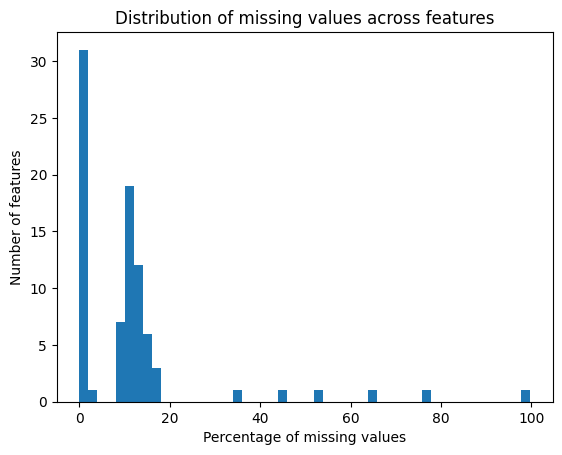

```python
# Investigate patterns in the amount of missing data in each column.
plt.hist(missing_percent, bins=50)
plt.xlabel("Percentage of missing values")
plt.ylabel("Number of features")
plt.title("Distribution of missing values across features")
plt.savefig("images/missing_val_dist_by_feature.png", bbox_inches="tight")
plt.show()
```

A threshold of 30% missing values is used to identify columns with excessive missingness, as such features are likely unreliable for analysis.

```python
high_missing_cols = missing_percent[missing_percent > 30].index.tolist()
high_missing_cols
```

```
['AGER_TYP',
 'GEBURTSJAHR',
 'TITEL_KZ',
 'ALTER_HH',
 'KK_KUNDENTYP',
 'KBA05_BAUMAX']
```

**Helper Functions**

```python
def drop_columns(df, drop_columns):
    df_copy = df.copy()
    df_copy = df_copy.drop(columns = drop_columns, errors="ignore")

    return df_copy
```

**Cleaning/Transformation**

```python
# Remove the outlier columns from the dataset. (You'll perform other data
# engineering tasks such as re-encoding and imputation later.)

df_demographics = drop_columns(df_demographics, high_missing_cols)
```

#### Discussion 1.1.2: Assess Missing Data in Each Column

The histogram shows that most features have low missingness (<30%), while a small number of features have significantly higher missing values.

The following columns exceed the 30% threshold and will be considered for removal:

- AGER_TYP
- GEBURTSJAHR
- TITEL_KZ
- ALTER_HH
- KK_KUNDENTYP
- KBA05_BAUMAX

#### Step 1.1.3: Assess Missing Data in Each Row

Now, you'll perform a similar assessment for the rows of the dataset. How much data is missing in each row? As with the columns, you should see some groups of points that have a very different numbers of missing values. Divide the data into two subsets: one for data points that are above some threshold for missing values, and a second subset for points below that threshold.

In order to know what to do with the outlier rows, we should see if the distribution of data values on columns that are not missing data (or are missing very little data) are similar or different between the two groups. Select at least five of these columns and compare the distribution of values.

- You can use seaborn's [`countplot()`](https://seaborn.pydata.org/generated/seaborn.countplot.html) function to create a bar chart of code frequencies and matplotlib's [`subplot()`](https://matplotlib.org/api/_as_gen/matplotlib.pyplot.subplot.html) function to put bar charts for the two subplots side by side.
- To reduce repeated code, you might want to write a function that can perform this comparison, taking as one of its arguments a column to be compared.

Depending on what you observe in your comparison, this will have implications on how you approach your conclusions later in the analysis. If the distributions of non-missing features look similar between the data with many missing values and the data with few or no missing values, then we could argue that simply dropping those points from the analysis won't present a major issue. On the other hand, if the data with many missing values looks very different from the data with few or no missing values, then we should make a note on those data as special. We'll revisit these data later on. **Either way, you should continue your analysis for now using just the subset of the data with few or no missing values.**

**Data Analysis**

```python
# How much data is missing in each row of the dataset?
row_missing = df_demographics.isnull().sum(axis=1)
row_missing.describe()
```

```
count    891221.000000
mean          5.649894
std          13.234687
min           0.000000
25%           0.000000
50%           0.000000
75%           3.000000
max          49.000000
dtype: float64
```

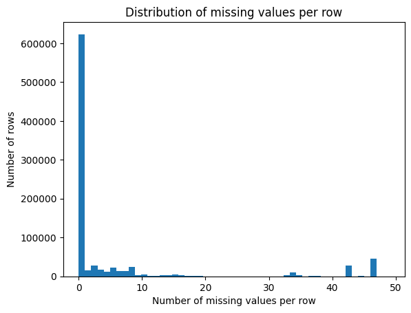

```python
plt.hist(row_missing, bins=50)
plt.xlabel("Number of missing values per row")
plt.ylabel("Number of rows")
plt.title("Distribution of missing values per row")
plt.show()
```

From the analysis above, 75% of the rows have 3 or less missing values. This is validated by the spike in the histogram for 0 missing values. There is a long tail of bad rows (32-50 missing values). A good threshold to separate the good rows from the bad rows is 20 missing values.

```python
# Write code to divide the data into two subsets based on the number of missing
# values in each row.

threshold = 20

low_missing = df_demographics[row_missing <= threshold]
high_missing = df_demographics[row_missing > threshold]

print(f"Rows with low missing values: {low_missing.shape[0]}")
print(f"Rows with high missing values: {high_missing.shape[0]}")
```

```
Rows with low missing values: 797426
Rows with high missing values: 93795
```

```python
low_missing_cols = missing_percent[missing_percent < 5].index.tolist()
low_missing_cols
```

```
['ALTERSKATEGORIE_GROB',
 'ANREDE_KZ',
 'CJT_GESAMTTYP',
 'FINANZ_MINIMALIST',
 'FINANZ_SPARER',
 'FINANZ_VORSORGER',
 'FINANZ_ANLEGER',
 'FINANZ_UNAUFFAELLIGER',
 'FINANZ_HAUSBAUER',
 'FINANZTYP',
 'GFK_URLAUBERTYP',
 'GREEN_AVANTGARDE',
 'LP_STATUS_FEIN',
 'LP_STATUS_GROB',
 'RETOURTYP_BK_S',
 'SEMIO_SOZ',
 'SEMIO_FAM',
 'SEMIO_REL',
 'SEMIO_MAT',
 'SEMIO_VERT',
 'SEMIO_LUST',
 'SEMIO_ERL',
 'SEMIO_KULT',
 'SEMIO_RAT',
 'SEMIO_KRIT',
 'SEMIO_DOM',
 'SEMIO_KAEM',
 'SEMIO_PFLICHT',
 'SEMIO_TRADV',
 'ZABEOTYP',
 'HH_EINKOMMEN_SCORE',
 'ONLINE_AFFINITAET']
```

From the low missing value columns above, picking one column from each group identified earlier.

- ANREDE_KZ - Demographics
- FINANZ_MINIMALIST - Financial
- SEMIO_SOZ - Personality
- HH_EINKOMMEN_SCORE - Household
- ONLINE_AFFINITAET - Behavior

```python
# Compare the distribution of values for at least five columns where there are
# no or few missing values, between the two subsets.

cols_to_compare = ["ANREDE_KZ", "FINANZ_MINIMALIST", "SEMIO_SOZ", "HH_EINKOMMEN_SCORE", "ONLINE_AFFINITAET"]
```

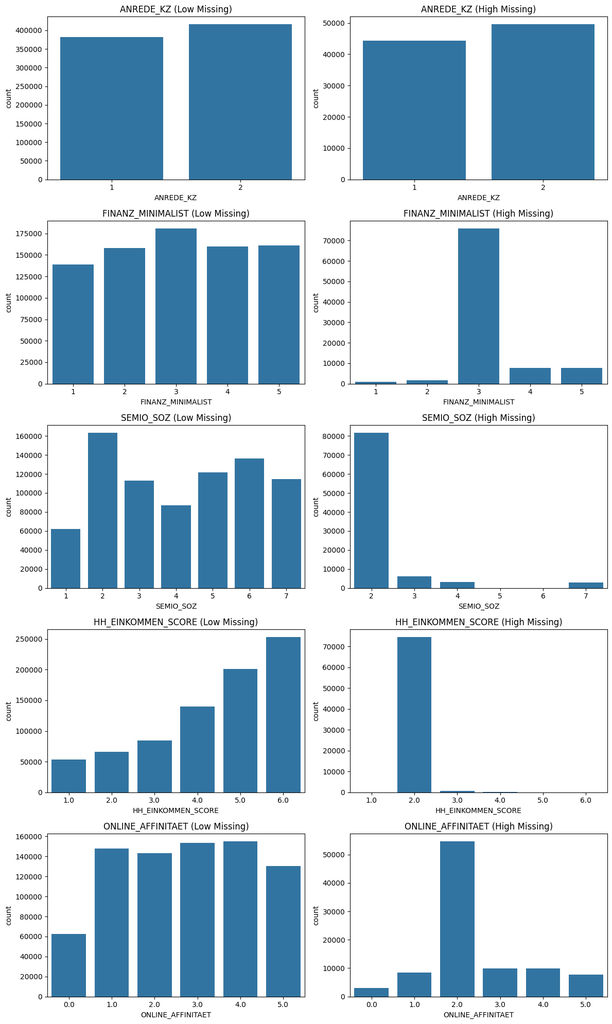

```python
fig, axes = plt.subplots(len(cols_to_compare), 2, figsize=(12, 4 * len(cols_to_compare)))

for i, col in enumerate(cols_to_compare):
    sns.countplot(x=low_missing[col], ax=axes[i, 0])
    axes[i, 0].set_title(f"{col} (Low Missing)")

    sns.countplot(x=high_missing[col], ax=axes[i, 1])
    axes[i, 1].set_title(f"{col} (High Missing)")

plt.tight_layout()
plt.show()
```

```python
df_demographics = low_missing.copy()
```

#### Discussion 1.1.3: Assess Missing Data in Each Row

The distributions of several features differ significantly between rows with low and high missingness.

Rows with high missingness tend to have less diverse and more concentrated feature values, suggesting that they may represent a biased or incomplete subset of the population.

Given their limited representation and high level of missing data, these rows are likely to introduce noise rather than meaningful signal. Therefore, they will be removed from further analysis.

### Step 1.2: Select and Re-Encode Features

Checking for missing data isn't the only way in which you can prepare a dataset for analysis. Since the unsupervised learning techniques to be used will only work on data that is encoded numerically, you need to make a few encoding changes or additional assumptions to be able to make progress. In addition, while almost all of the values in the dataset are encoded using numbers, not all of them represent numeric values. Check the third column of the feature summary (`feat_info`) for a summary of types of measurement.

- For numeric and interval data, these features can be kept without changes.
- Most of the variables in the dataset are ordinal in nature. While ordinal values may technically be non-linear in spacing, make the simplifying assumption that the ordinal variables can be treated as being interval in nature (that is, kept without any changes).
- Special handling may be necessary for the remaining two variable types: categorical, and 'mixed'.

In the first two parts of this sub-step, you will perform an investigation of the categorical and mixed-type features and make a decision on each of them, whether you will keep, drop, or re-encode each. Then, in the last part, you will create a new data frame with only the selected and engineered columns.

Data wrangling is often the trickiest part of the data analysis process, and there's a lot of it to be done here. But stick with it: once you're done with this step, you'll be ready to get to the machine learning parts of the project!

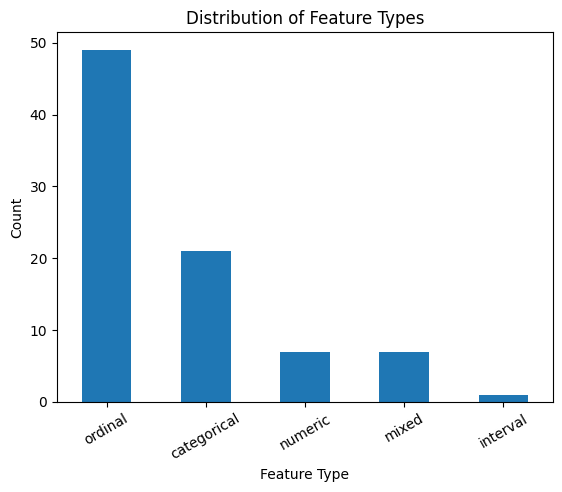

```python
# How many features are there of each data type?

df_feature_summary["type"].value_counts().plot(kind="bar")
plt.title("Distribution of Feature Types")
plt.xlabel("Feature Type")
plt.xticks(rotation=30)
plt.ylabel("Count")
plt.savefig("images/feature_type_dist.png", bbox_inches="tight")
plt.show()
```

The dataset is dominated by ordinal features, which can be treated as interval variables for modeling purposes.

A smaller number of categorical and mixed-type features require additional processing:

- Categorical features will be re-encoded
- Mixed-type features will be decomposed into meaningful components

Numeric and interval features can be retained without modification.

#### Step 1.2.1: Re-Encode Categorical Features

For categorical data, you would ordinarily need to encode the levels as dummy variables. Depending on the number of categories, perform one of the following:

- For binary (two-level) categoricals that take numeric values, you can keep them without needing to do anything.
- There is one binary variable that takes on non-numeric values. For this one, you need to re-encode the values as numbers or create a dummy variable.
- For multi-level categoricals (three or more values), you can choose to encode the values using multiple dummy variables (e.g. via [OneHotEncoder](http://scikit-learn.org/stable/modules/generated/sklearn.preprocessing.OneHotEncoder.html)), or (to keep things straightforward) just drop them from the analysis. As always, document your choices in the Discussion section.

**Data Analysis**

```python
# Assess categorical variables: which are binary, which are multi-level, and
# which one needs to be re-encoded?

categorical_features = [
    col for col in df_feature_summary[df_feature_summary["type"] == "categorical"]["attribute"].tolist()
    if col in df_demographics.columns
]
categorical_features
```

```
['ANREDE_KZ',
 'CJT_GESAMTTYP',
 'FINANZTYP',
 'GFK_URLAUBERTYP',
 'GREEN_AVANTGARDE',
 'LP_FAMILIE_FEIN',
 'LP_FAMILIE_GROB',
 'LP_STATUS_FEIN',
 'LP_STATUS_GROB',
 'NATIONALITAET_KZ',
 'SHOPPER_TYP',
 'SOHO_KZ',
 'VERS_TYP',
 'ZABEOTYP',
 'GEBAEUDETYP',
 'OST_WEST_KZ',
 'CAMEO_DEUG_2015',
 'CAMEO_DEU_2015']
```

Identify categorical features with binary values vs multiiple values. Re-encode only for features with multiple values

```python
# Binary categorical features
binary_features = [col for col in categorical_features if df_demographics[col].dropna().nunique() == 2]
binary_features
```

```
['ANREDE_KZ', 'GREEN_AVANTGARDE', 'SOHO_KZ', 'VERS_TYP', 'OST_WEST_KZ']
```

```python
# Multi-level categorical features
multi_level_features = [col for col in categorical_features if df_demographics[col].dropna().nunique() > 2]
multi_level_features
```

```
['CJT_GESAMTTYP',
 'FINANZTYP',
 'GFK_URLAUBERTYP',
 'LP_FAMILIE_FEIN',
 'LP_FAMILIE_GROB',
 'LP_STATUS_FEIN',
 'LP_STATUS_GROB',
 'NATIONALITAET_KZ',
 'SHOPPER_TYP',
 'ZABEOTYP',
 'GEBAEUDETYP',
 'CAMEO_DEUG_2015',
 'CAMEO_DEU_2015']
```

```python
for col in multi_level_features:
    print(f"\n {col} :")
    print(df_demographics[col].value_counts().head())
```

```
 CJT_GESAMTTYP :
CJT_GESAMTTYP
4.0    198169
3.0    147134
2.0    141212
5.0    111058
6.0    101955
Name: count, dtype: int64

 FINANZTYP :
FINANZTYP
6    289021
1    196893
5    106270
2    104688
4     55886
Name: count, dtype: int64

 GFK_URLAUBERTYP :
GFK_URLAUBERTYP
12.0    130093
10.0    102784
8.0      83014
11.0     75070
5.0      70482
Name: count, dtype: int64

 LP_FAMILIE_FEIN :
LP_FAMILIE_FEIN
1.0     402379
10.0    128924
2.0      98522
11.0     48734
8.0      21778
Name: count, dtype: int64

 LP_FAMILIE_GROB :
LP_FAMILIE_GROB
1.0    402379
5.0    188110
```

[output cut: 58 more lines]

```
8    134408
9    108152
6    105840
4    103842
3     86666
Name: count, dtype: int64

 CAMEO_DEU_2015 :
CAMEO_DEU_2015
6B    56653
8A    52430
4C    47779
2D    35059
3C    34753
Name: count, dtype: int64
```

```python
df_demographics["CAMEO_DEU_2015"].dropna().unique()[:10]
```

```
array(['8A', '4C', '2A', '6B', '8C', '4A', '2D', '1A', '1E', '9D'],
      dtype=object)
```

**Helper Functions**

```python
def transform_OST_WEST_KZ(df):
    df_copy = df.copy()

    if "OST_WEST_KZ" in df_copy.columns:
        df_copy["OST_WEST_KZ"] = df_copy["OST_WEST_KZ"].map({"W":0, "O":1})

    return df_copy
```

**Cleaning/Transformation**

```python
# Re-encode categorical variable(s) to be kept in the analysis.
df_demographics = transform_OST_WEST_KZ(df_demographics)
```

```python
# Drop multi-level categorical features except CAMEO_DEU_2015
multi_level_features = [col for col in multi_level_features if col != "CAMEO_DEU_2015"]

df_demographics = drop_columns(df_demographics, multi_level_features)
```

#### Discussion 1.2.1: Re-Encode Categorical Features

Categorical features were grouped into binary and multi-level categories and handled accordingly.

**Binary categorical features:**  
Binary features such as `ANREDE_KZ`, `GREEN_AVANTGARDE`, `SOHO_KZ`, and `VERS_TYP` were retained as numeric values since they are already encoded in a format suitable for analysis.  
The binary non-numeric feature `OST_WEST_KZ` was re-encoded into numeric form to ensure consistency across the dataset.

**Multi-level categorical features:**  
A review of multi-level categorical features shows that most represent discrete category labels without inherent ordering or decomposable structure. Examples include `CJT_GESAMTTYP`, `FINANZTYP`, and `ZABEOTYP`, where numeric codes correspond to distinct, non-ordinal categories.

Some features (e.g., `LP_FAMILIE_FEIN` and `LP_FAMILIE_GROB`) provide overlapping or hierarchical information, increasing redundancy. Other features such as `NATIONALITAET_KZ` exhibit highly imbalanced distributions, limiting their usefulness for clustering.

Encoding these features using one-hot encoding would significantly increase dimensionality without clear benefit for unsupervised learning. Therefore, these multi-level categorical features were removed from the analysis.

**Exception – structured categorical feature:**  
`CAMEO_DEU_2015` was treated as an exception because its values follow a structured alphanumeric pattern (e.g., "6B", "8A") that encodes multiple dimensions of information. This feature was decomposed into meaningful numerical components (e.g., wealth and lifestyle), allowing it to be retained in a model-friendly format. The lifestyle component was not retained due to its categorical nature and lack of clear ordinal interpretation.

Overall, this approach ensures that the dataset remains numerically consistent while avoiding unnecessary expansion of the feature space.

#### Step 1.2.2: Engineer Mixed-Type Features

There are a handful of features that are marked as "mixed" in the feature summary that require special treatment in order to be included in the analysis. There are two in particular that deserve attention; the handling of the rest are up to your own choices:

- "PRAEGENDE_JUGENDJAHRE" combines information on three dimensions: generation by decade, movement (mainstream vs. avantgarde), and nation (east vs. west). While there aren't enough levels to disentangle east from west, you should create two new variables to capture the other two dimensions: an interval-type variable for decade, and a binary variable for movement.
- "CAMEO_INTL_2015" combines information on two axes: wealth and life stage. Break up the two-digit codes by their 'tens'-place and 'ones'-place digits into two new ordinal variables (which, for the purposes of this project, is equivalent to just treating them as their raw numeric values).
- If you decide to keep or engineer new features around the other mixed-type features, make sure you note your steps in the Discussion section.

Be sure to check `Data_Dictionary.md` for the details needed to finish these tasks.

**Helper Functions(s)**

*Mixed Feature Transformations*

Mixed-type features contain multiple pieces of information encoded within a single variable. Rather than dropping them, these features are decomposed into more interpretable components.

The following transformations are applied:

```python
def get_youth_movement(code):
    if pd.isna(code):
        return np.nan

    code = int(code)

    mainstream = {1, 3, 5, 8, 10, 12, 14}
    avantgarde = {2, 4, 6, 7, 9, 11, 13, 15}

    # Based on data dictionary:
    # Codes represent youth movement types:
    # 0 → mainstream
    # 1 → avantgarde
    if code in mainstream:
        return 0
    elif code in avantgarde:
        return 1

    return np.nan
```

```python
def get_youth_region(code):
    if pd.isna(code):
        return np.nan

    code = int(code)

    west = {6, 10, 11}
    east = {7, 12, 13}

    # Based on data dictionary:
    # 0 → West Germany
    # 1 → East Germany

    if code in west:
        return 0
    elif code in east:
        return 1

    return np.nan
```

```python
def transform_PRAEGENDE_JUGENDJAHRE(df):
    print_debug_info("Enter: transform_PRAEGENDE_JUGENDJAHRE")
    df_copy = df.copy()

    if "PRAEGENDE_JUGENDJAHRE" in df_copy.columns:
        # Extract the youth movement and region
        df_copy["YOUTH_MOVEMENT"] = df_copy["PRAEGENDE_JUGENDJAHRE"].apply(get_youth_movement)
        df_copy["YOUTH_REGION"] = df_copy["PRAEGENDE_JUGENDJAHRE"].apply(get_youth_region)

        df_copy = df_copy.drop(columns=["PRAEGENDE_JUGENDJAHRE"], errors="ignore")

        print_debug_info(f' YOUTH_MOVEMENT value_counts: {df_copy["YOUTH_MOVEMENT"].value_counts(dropna=False)}')
        print_debug_info(f' YOUTH_REGION value_counts: {df_copy["YOUTH_REGION"].value_counts(dropna=False)}')

    return df_copy
```

```python
def transform_CAMEO_DEU_2015(df):
    print_debug_info("Enter: transform_CAMEO_DEU_2015")
    # Split wealth and lifestyle
    df_copy = df.copy()

    if "CAMEO_DEU_2015" in df_copy.columns:
        # keep NaNs as NaN
        s = df_copy["CAMEO_DEU_2015"].astype("string")

        # Keep only wealth (ordinal, useful for clustering)
        df_copy["CAMEO_WEALTH"] = pd.to_numeric(s.str[0], errors="coerce")
        # df_copy["CAMEO_LIFESTYLE"] = s.str[1]

        df_copy = df_copy.drop(columns=["CAMEO_DEU_2015"], errors="ignore")

        print_debug_info(f' CAMEO_WEALTH value_counts: {df_copy["CAMEO_WEALTH"].value_counts(dropna=False).sort_index()}')

    return df_copy
```

```python
def transform_CAMEO_INTL_2015(df):
    print_debug_info("Enter: transform_CAMEO_INTL_2015")
    # Split wealth and lifestyle
    df_copy = df.copy()

    if "CAMEO_INTL_2015" in df_copy.columns:
        s = df_copy["CAMEO_INTL_2015"].astype("string")

        # Keep only wealth (ordinal, useful for clustering)
        df_copy["CAMEO_INTL_WEALTH"] = pd.to_numeric(s.str[0], errors="coerce")
        # df_copy["CAMEO_INTL_LIFE_STAGE"] = pd.to_numeric(s.str[1], errors="coerce")

        df_copy = df_copy.drop(columns=["CAMEO_INTL_2015"], errors="ignore")

        print_debug_info(f' CAMEO_INTL_WEALTH value_counts: {df_copy["CAMEO_INTL_WEALTH"].value_counts(dropna=False).sort_index()}')

    return df_copy
```

Investigate "PRAEGENDE_JUGENDJAHRE" and engineer two new variables.

- 1: 40s - war years (Mainstream, E+W)
- 2: 40s - reconstruction years (Avantgarde, E+W)
- 3: 50s - economic miracle (Mainstream, E+W)

Youth movement and region are stored within (). Extract these into 2 separate features in the dataset

```python
df_demographics = transform_PRAEGENDE_JUGENDJAHRE(df_demographics)
```

11: Wealthy Households - Pre-Family Couples & Singles 12: Wealthy Households - Young Couples With Children 13: Wealthy Households - Families With School Age Children

```python
# Investigate "CAMEO_INTL_2015" and engineer two new variables.

df_demographics = transform_CAMEO_DEU_2015(df_demographics)
df_demographics = transform_CAMEO_INTL_2015(df_demographics)
```

#### Discussion 1.2.2: Engineer Mixed-Type Features

The mixed features were decomposed into simpler components and the original encoded columns were removed. This preserves useful information while making the dataset more suitable for downstream modeling.

The CAMEO features were decomposed into wealth-related components. Only the wealth dimension was retained, as it provides meaningful ordinal information for clustering. Other components were not included to avoid introducing non-ordinal categorical variables.

> Note: The `YOUTH_MOVEMENT` feature overlaps conceptually with `GREEN_AVANTGARDE`, but provides additional historical context based on youth classification. Both are retained for analysis.

> The derived feature `YOUTH_REGION` captures regional information similar to `OST_WEST_KZ`, but is based on historical classification. Both are retained as they may capture different aspects of regional variation.

#### Step 1.2.3: Complete Feature Selection

In order to finish this step up, you need to make sure that your data frame now only has the columns that you want to keep. To summarize, the dataframe should consist of the following:

- All numeric, interval, and ordinal type columns from the original dataset.
- Binary categorical features (all numerically-encoded).
- Engineered features from other multi-level categorical features and mixed features.

Make sure that for any new columns that you have engineered, that you've excluded the original columns from the final dataset. Otherwise, their values will interfere with the analysis later on the project. For example, you should not keep "PRAEGENDE_JUGENDJAHRE", since its values won't be useful for the algorithm: only the values derived from it in the engineered features you created should be retained. As a reminder, your data should only be from **the subset with few or no missing values**.

`WOHNLAGE` represents residential location quality on an ordinal scale. According to the data dictionary, a value of 0 indicates missing or uncalculated data. These values are converted to NaN to ensure consistent handling of missing data.

The feature is otherwise retained as a numeric variable for modeling.

```python
def transform_WOHNLAGE(df):
    print_debug_info("Enter: transform_WOHNLAGE")
    # Normalize the values
    df_copy = df.copy()
    if "WOHNLAGE" in df_copy.columns:
        df_copy["WOHNLAGE"] = pd.to_numeric(df_copy["WOHNLAGE"], errors="coerce")

        # As per data dictionary 0 is not calculated. So set it to nan
        df_copy.loc[df_copy["WOHNLAGE"] == 0, "WOHNLAGE"] = np.nan

        print_debug_info(df_copy["WOHNLAGE"].describe())

    return df_copy
```

Values below 18 and extreme outliers above 100 are treated as missing to reduce noise from implausible records.

```python
def transform_GEBURTSJAHR(df):
    print_debug_info("Enter: transform_GEBURTSJAHR")

    df_copy = df.copy()
    if "GEBURTSJAHR" in df_copy.columns:
        # Convert birth year to age using 2017 as the reference year for the dataset
        df_copy["AGE"] = 2017 - df_copy["GEBURTSJAHR"]
        df_copy = df_copy.drop(columns=["GEBURTSJAHR"], errors="ignore")

        # Ages below 18 and extremely high values above 100 are treated as implausible or
        # outlier values for this analysis and set to NaN
        df_copy.loc[(df_copy["AGE"] < 18) | (df_copy["AGE"] > 100), "AGE"] = np.nan

        print_debug_info(df_copy["AGE"].describe())
        print_debug_info(f'AGE empty values: {df_copy["AGE"].isna().sum()}')

    return df_copy
```

No further transformation is applied, as the feature is already numeric and suitable for modeling.

```python
def transform_ALTER_HH(df):
    print_debug_info("Enter: transform_ALTER_HH")
    df_copy = df.copy()

    # To keep it consistent with the AGE column, renaming the household age column to HH_AGE
    if "ALTER_HH" in df_copy.columns:
        df_copy = df_copy.rename(columns={"ALTER_HH":"HH_AGE"})

    df_copy.loc[df_copy["HH_AGE"] == 0, "HH_AGE"] = np.nan

    print_debug_info(df_copy["HH_AGE"].describe())
    print_debug_info(f'HH_AGE empty values: {df_copy["HH_AGE"].isna().sum()}')

    return df_copy
```

`MIN_GEBAEUDEJAHR` is transformed into `BUILDING_AGE` to create a more interpretable feature for clustering. Building age is calculated using 2017 as the reference year for the dataset.

Negative values and extreme outliers above 100 years are treated as missing to reduce noise from implausible records.

```python
def transform_MIN_GEBAEUDEJAHR(df):
    print_debug_info("Enter: transform_MIN_GEBAEUDEJAHR")

    df_copy = df.copy()
    if "MIN_GEBAEUDEJAHR" in df_copy.columns:
        # Convert building year to building age using 2017 as the dataset reference year
        df_copy["BUILDING_AGE"] = 2017 - df_copy["MIN_GEBAEUDEJAHR"]
        df_copy = df_copy.drop(columns=["MIN_GEBAEUDEJAHR"], errors="ignore")

        # Treat implausible or extreme values as missing
        df_copy.loc[(df_copy["BUILDING_AGE"] < 0) | (df_copy["BUILDING_AGE"] > 100), "BUILDING_AGE"] = np.nan

        print_debug_info(df_copy["BUILDING_AGE"].describe())
        print_debug_info(f'BUILDING_AGE empty values: {df_copy["BUILDING_AGE"].isna().sum()}')

    return df_copy
```

```python
# If there are other re-engineering tasks you need to perform, make sure you
# take care of them here. (Dealing with missing data will come in step 2.1.)

df_demographics = transform_WOHNLAGE (df_demographics)
df_demographics = transform_GEBURTSJAHR(df_demographics)
df_demographics = transform_MIN_GEBAEUDEJAHR(df_demographics)
```

```python
# Do whatever you need to in order to ensure that the dataframe only contains
# the columns that should be passed to the algorithm functions.

df_demographics.columns
```

```
Index(['ALTERSKATEGORIE_GROB', 'ANREDE_KZ', 'FINANZ_MINIMALIST',
       'FINANZ_SPARER', 'FINANZ_VORSORGER', 'FINANZ_ANLEGER',
       'FINANZ_UNAUFFAELLIGER', 'FINANZ_HAUSBAUER', 'GREEN_AVANTGARDE',
       'HEALTH_TYP', 'LP_LEBENSPHASE_FEIN', 'LP_LEBENSPHASE_GROB',
       'RETOURTYP_BK_S', 'SEMIO_SOZ', 'SEMIO_FAM', 'SEMIO_REL', 'SEMIO_MAT',
       'SEMIO_VERT', 'SEMIO_LUST', 'SEMIO_ERL', 'SEMIO_KULT', 'SEMIO_RAT',
       'SEMIO_KRIT', 'SEMIO_DOM', 'SEMIO_KAEM', 'SEMIO_PFLICHT', 'SEMIO_TRADV',
       'SOHO_KZ', 'VERS_TYP', 'ANZ_PERSONEN', 'ANZ_TITEL',
       'HH_EINKOMMEN_SCORE', 'W_KEIT_KIND_HH', 'WOHNDAUER_2008',
       'ANZ_HAUSHALTE_AKTIV', 'ANZ_HH_TITEL', 'KONSUMNAEHE', 'OST_WEST_KZ',
       'WOHNLAGE', 'KBA05_ANTG1', 'KBA05_ANTG2', 'KBA05_ANTG3', 'KBA05_ANTG4',
       'KBA05_GBZ', 'BALLRAUM', 'EWDICHTE', 'INNENSTADT', 'GEBAEUDETYP_RASTER',
       'KKK', 'MOBI_REGIO', 'ONLINE_AFFINITAET', 'REGIOTYP',
       'KBA13_ANZAHL_PKW', 'PLZ8_ANTG1', 'PLZ8_ANTG2', 'PLZ8_ANTG3',
       'PLZ8_ANTG4', 'PLZ8_BAUMAX', 'PLZ8_HHZ', 'PLZ8_GBZ', 'ARBEIT',
       'ORTSGR_KLS9', 'RELAT_AB', 'YOUTH_MOVEMENT', 'YOUTH_REGION',
       'CAMEO_WEALTH', 'CAMEO_INTL_WEALTH', 'BUILDING_AGE'],
      dtype='object')
```

### Step 1.3: Create a Cleaning Function

Even though you've finished cleaning up the general population demographics data, it's important to look ahead to the future and realize that you'll need to perform the same cleaning steps on the customer demographics data. In this substep, complete the function below to execute the main feature selection, encoding, and re-engineering steps you performed above. Then, when it comes to looking at the customer data in Step 3, you can just run this function on that DataFrame to get the trimmed dataset in a single step.

```python
def apply_transformations(df):
    print_debug_info("Enter: apply_transformation")

    df_copy = df.copy()

    df_copy = transform_GEBURTSJAHR(df_copy)
    df_copy = transform_PRAEGENDE_JUGENDJAHRE(df_copy)
    df_copy = transform_WOHNLAGE(df_copy)
    df_copy = transform_CAMEO_INTL_2015(df_copy)
    df_copy = transform_CAMEO_DEU_2015(df_copy)
    df_copy = transform_OST_WEST_KZ(df_copy)
    df_copy = transform_MIN_GEBAEUDEJAHR(df_copy)

    return df_copy
```

The transformations developed in the previous sections are consolidated into a reusable helper function. This ensures that the same feature-engineering logic can later be applied consistently to the customer dataset.

```python
def clean_data(df):
    """
    Perform feature trimming, re-encoding, and engineering for demographics
    data

    INPUT: Demographics DataFrame
    OUTPUT: Trimmed and cleaned demographics DataFrame
    """

    print_debug_info("Enter: clean_data")

    df_copy = df.copy()

    # Step 1: Standardize missing values
    df_copy = standardize_missing_values(df_copy, df_feature_summary)

    # Step 2: Drop columns with high missing values
    df_copy = df_copy.drop(columns=high_missing_cols, errors="ignore")

    # Step 3: Drop multi-level feature columns
    # df_copy = df_copy.drop(columns=multi_level_features_to_drop, errors="ignore")
    df_copy = drop_columns(df_copy, multi_level_features)

    # Step 4: Apply feature transformations
    df_copy = apply_transformations(df_copy)

    return df_copy
```

## Step 2: Feature Transformation

### Step 2.1: Apply Feature Scaling

Before we apply dimensionality reduction techniques to the data, we need to perform feature scaling so that the principal component vectors are not influenced by the natural differences in scale for features. Starting from this part of the project, you'll want to keep an eye on the [API reference page for sklearn](http://scikit-learn.org/stable/modules/classes.html) to help you navigate to all of the classes and functions that you'll need. In this substep, you'll need to check the following:

- sklearn requires that data not have missing values in order for its estimators to work properly. So, before applying the scaler to your data, make sure that you've cleaned the DataFrame of the remaining missing values. This can be as simple as just removing all data points with missing data, or applying an [SimpleImputer](https://scikit-learn.org/stable/modules/generated/sklearn.impute.SimpleImputer.html) to replace all missing values. You might also try a more complicated procedure where you temporarily remove missing values in order to compute the scaling parameters before re-introducing those missing values and applying imputation. Think about how much missing data you have and what possible effects each approach might have on your analysis, and justify your decision in the discussion section below.
- For the actual scaling function, a [StandardScaler](http://scikit-learn.org/stable/modules/generated/sklearn.preprocessing.StandardScaler.html) instance is suggested, scaling each feature to mean 0 and standard deviation 1.
- For these classes, you can make use of the `.fit_transform()` method to both fit a procedure to the data as well as apply the transformation to the data at the same time. Don't forget to keep the fit sklearn objects handy, since you'll be applying them to the customer demographics data towards the end of the project.

```python
# If you've not yet cleaned the dataset of all NaN values, then investigate and
# do that now.

non_numeric_cols = df_demographics.columns[
    ~df_demographics.apply(lambda s: pd.api.types.is_numeric_dtype(s))
]
non_numeric_cols
```

```
Index([], dtype='object')
```

```python
#  Impute
imputer = SimpleImputer(strategy="median")
df_imputed = pd.DataFrame(
    imputer.fit_transform(df_demographics),
    columns = df_demographics.columns
)
```

```python
# Apply feature scaling to the general population demographics data.
scaler = StandardScaler()
X_scaled = scaler.fit_transform(df_imputed)
```

### Discussion 2.1: Apply Feature Scaling

Before applying PCA, the dataset was prepared by handling remaining missing values and scaling features.

All remaining missing values were imputed using the median. Median imputation was chosen because it is robust to outliers and appropriate for the predominantly ordinal and numeric features in the dataset. This approach allows retention of all data points while minimizing distortion from extreme values.

After imputation, feature scaling was performed using `StandardScaler`, which standardizes each feature to have mean 0 and standard deviation 1. This step is essential for PCA, as it ensures that features with larger numeric ranges do not disproportionately influence the principal components.

The fitted imputer and scaler were retained so that the same transformations can be consistently applied to the customer dataset in later steps.

Since earlier preprocessing ensured that only numeric features remained, no additional encoding was required prior to scaling.

### Step 2.2: Perform Dimensionality Reduction

On your scaled data, you are now ready to apply dimensionality reduction techniques.

- Use sklearn's [PCA](http://scikit-learn.org/stable/modules/generated/sklearn.decomposition.PCA.html) class to apply principal component analysis on the data, thus finding the vectors of maximal variance in the data. To start, you should not set any parameters (so all components are computed) or set a number of components that is at least half the number of features (so there's enough features to see the general trend in variability).
- Check out the ratio of variance explained by each principal component as well as the cumulative variance explained. Try plotting the cumulative or sequential values using matplotlib's [`plot()`](https://matplotlib.org/api/_as_gen/matplotlib.pyplot.plot.html) function. Based on what you find, select a value for the number of transformed features you'll retain for the clustering part of the project.
- Once you've made a choice for the number of components to keep, make sure you re-fit a PCA instance to perform the decided-on transformation.

Principal Component Analysis (PCA) is applied to reduce the dimensionality of the dataset while retaining most of the variance.

First, PCA is fit without restricting the number of components to analyze how much variance each component explains. The cumulative explained variance is then examined to determine an appropriate number of components to retain.

```python
# Apply PCA to the data.

pca = PCA()
pca.fit(X_scaled)

explained_variance = pca.explained_variance_ratio_
cumulative_variance = np.cumsum(explained_variance)
```

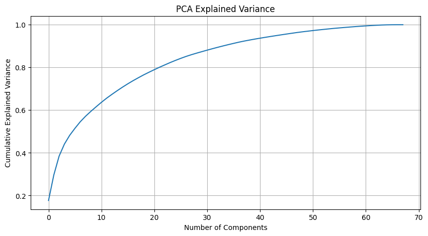

```python
# Investigate the variance accounted for by each principal component.

plt.figure(figsize=(10,5))
plt.plot(cumulative_variance)
plt.xlabel("Number of Components")
plt.ylabel("Cumulative Explained Variance")
plt.title("PCA Explained Variance")
plt.grid()
plt.savefig("images/pca_explained_variance.png", bbox_inches="tight")
plt.show()
```

```python
for i, val in enumerate(cumulative_variance):
    if val >= 0.85:
        print(f"85% variance at {i+1} components")
        break
```

```
85% variance at 27 components
```

```python
for i, val in enumerate(cumulative_variance):
    if val >= 0.80:
        print(f"80% variance at {i+1} components")
        break
```

```
80% variance at 22 components
```

```python
n_components = np.argmax(cumulative_variance >= 0.85) + 1
n_components
```

```
27
```

```python
# Re-apply PCA to the data while selecting for number of components to retain.
pca = PCA(n_components=n_components)
X_pca = pca.fit_transform(X_scaled)
```

### Discussion 2.2: Perform Dimensionality Reduction

PCA was applied to the scaled dataset to reduce dimensionality while preserving the structure of the data.

The number of principal components was selected based on cumulative explained variance. Approximately 80% of the variance is captured by 22 components; however, 27 components were retained to capture additional variance (~85%) and avoid excessive information loss while still reducing dimensionality.

Therefore, 27 components were selected for the final transformation. This reduces noise and computational complexity while preserving the majority of the dataset’s variance for clustering.

### Step 2.3: Interpret Principal Components

Now that we have our transformed principal components, it's a nice idea to check out the weight of each variable on the first few components to see if they can be interpreted in some fashion.

As a reminder, each principal component is a unit vector that points in the direction of highest variance (after accounting for the variance captured by earlier principal components). The further a weight is from zero, the more the principal component is in the direction of the corresponding feature. If two features have large weights of the same sign (both positive or both negative), then increases in one tend expect to be associated with increases in the other. To contrast, features with different signs can be expected to show a negative correlation: increases in one variable should result in a decrease in the other.

- To investigate the features, you should map each weight to their corresponding feature name, then sort the features according to weight. The most interesting features for each principal component, then, will be those at the beginning and end of the sorted list. Use the data dictionary document to help you understand these most prominent features, their relationships, and what a positive or negative value on the principal component might indicate.
- You should investigate and interpret feature associations from the first three principal components in this substep. To help facilitate this, you should write a function that you can call at any time to print the sorted list of feature weights, for the *i*-th principal component. This might come in handy in the next step of the project, when you interpret the tendencies of the discovered clusters.

To better understand the structure of the data after dimensionality reduction, the feature weights for the first few principal components are examined.

Features with large positive or negative weights contribute most strongly to each principal component and help reveal underlying patterns in the data.

```python
# Map weights for the first principal component to corresponding feature names
# and then print the linked values, sorted by weight.
# HINT: Try defining a function here or in a new cell that you can reuse in the
# other cells.

def print_pca_weights(pca, feature_names, component_idx, top_n=10):
    weights = pd.Series(pca.components_[component_idx], index=feature_names)
    print(f"Principal component {component_idx +1}")
    print(f"Top positive features: {weights.sort_values(ascending=False).head(top_n)}")
    print(f"Top negative features: {weights.sort_values().head(top_n)}")

feature_names = df_demographics.columns

print_pca_weights(pca, feature_names, 0)
```

```
Principal component 1
Top positive features: MOBI_REGIO             0.236834
PLZ8_ANTG1             0.224184
KBA05_ANTG1            0.216501
KBA05_GBZ              0.211330
FINANZ_MINIMALIST      0.189708
PLZ8_GBZ               0.167017
KONSUMNAEHE            0.166381
INNENSTADT             0.162173
LP_LEBENSPHASE_FEIN    0.144339
LP_LEBENSPHASE_GROB    0.131064
dtype: float64
Top negative features: PLZ8_ANTG3           -0.223814
PLZ8_ANTG4           -0.217585
PLZ8_BAUMAX          -0.212689
CAMEO_WEALTH         -0.210153
CAMEO_INTL_WEALTH    -0.207707
HH_EINKOMMEN_SCORE   -0.198481
ORTSGR_KLS9          -0.195948
EWDICHTE             -0.193630
FINANZ_HAUSBAUER     -0.168098
KBA05_ANTG4          -0.153711
dtype: float64
```

```python
# Map weights for the second principal component to corresponding feature names
# and then print the linked values, sorted by weight.

print_pca_weights(pca, feature_names, 1)
```

```
Principal component 2
Top positive features: SEMIO_REL                0.287925
FINANZ_SPARER            0.256292
SEMIO_KULT               0.254310
SEMIO_PFLICHT            0.250909
SEMIO_TRADV              0.249365
FINANZ_UNAUFFAELLIGER    0.233005
SEMIO_FAM                0.220485
FINANZ_ANLEGER           0.205719
SEMIO_MAT                0.188117
SEMIO_RAT                0.179639
dtype: float64
Top negative features: ALTERSKATEGORIE_GROB   -0.282957
SEMIO_ERL              -0.261695
FINANZ_VORSORGER       -0.246659
SEMIO_LUST             -0.196372
RETOURTYP_BK_S         -0.159210
SEMIO_KRIT             -0.135426
SEMIO_KAEM             -0.128529
ANREDE_KZ              -0.114290
W_KEIT_KIND_HH         -0.104785
FINANZ_MINIMALIST      -0.101067
dtype: float64
```

```python
# Map weights for the third principal component to corresponding feature names
# and then print the linked values, sorted by weight.

print_pca_weights(pca, feature_names, 2)
```

```
Principal component 3
Top positive features: ANREDE_KZ                0.361679
SEMIO_KAEM               0.328753
SEMIO_DOM                0.307648
SEMIO_KRIT               0.266375
SEMIO_RAT                0.241100
FINANZ_ANLEGER           0.211936
SEMIO_ERL                0.150186
FINANZ_SPARER            0.134141
FINANZ_UNAUFFAELLIGER    0.121897
SEMIO_PFLICHT            0.108897
dtype: float64
Top negative features: SEMIO_VERT             -0.342729
SEMIO_SOZ              -0.251219
SEMIO_FAM              -0.227475
SEMIO_KULT             -0.209830
FINANZ_MINIMALIST      -0.176935
FINANZ_VORSORGER       -0.125219
RETOURTYP_BK_S         -0.122877
ALTERSKATEGORIE_GROB   -0.110883
W_KEIT_KIND_HH         -0.094181
SEMIO_LUST             -0.086323
dtype: float64
```

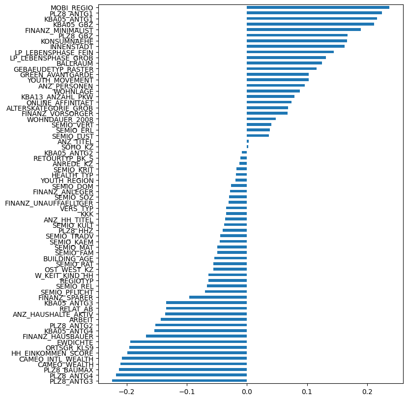

```python
weights = pd.Series(pca.components_[0], index=feature_names)
weights.sort_values().plot(kind="barh", figsize=(8,10))
```

### Discussion 2.3: Interpret Principal Components

The first three principal components capture key patterns in the dataset:

**Principal Component 2: Traditional vs Modern Lifestyle Orientation**

The second component captures differences in personal values and financial behavior.

Positive weights are associated with features such as `SEMIO_REL`, `SEMIO_TRADV`, and `FINANZ_SPARER`, which reflect traditional, conservative, and savings-oriented behavior. Negative weights include `SEMIO_ERL`, `SEMIO_LUST`, and `FINANZ_VORSORGER`, indicating more modern, experience-driven, and risk-oriented behavior.

This component appears to represent a spectrum from traditional, conservative individuals to more modern, experience-seeking individuals.

**Principal Component 3: Gender and Personality Traits**

The third component is strongly influenced by gender and associated personality traits.

Positive weights include `ANREDE_KZ` and features such as `SEMIO_KAEM`, `SEMIO_DOM`, and `SEMIO_KRIT`, which reflect more dominant, assertive, and critical personality traits. Negative weights include `SEMIO_SOZ`, `SEMIO_FAM`, and `SEMIO_VERT`, which are associated with social, family-oriented, and cooperative tendencies.

This component appears to capture differences in gender-linked behavioral and personality characteristics.

Overall, the principal components reveal meaningful variation in socioeconomic status, lifestyle orientation, and personality traits, which are likely to be important drivers of clustering in the next step.

## Step 3: Clustering

### Step 3.1: Apply Clustering to General Population

You've assessed and cleaned the demographics data, then scaled and transformed them. Now, it's time to see how the data clusters in the principal components space. In this substep, you will apply k-means clustering to the dataset and use the average within-cluster distances from each point to their assigned cluster's centroid to decide on a number of clusters to keep.

- Use sklearn's KMeans class to perform k-means clustering on the PCA-transformed data.
- Then, compute the average difference from each point to its assigned cluster's center. **Hint**: The KMeans object's `.score()` method might be useful here, but note that in sklearn, scores tend to be defined so that larger is better. Try applying it to a small, toy dataset, or use an internet search to help your understanding.
- Perform the above two steps for a number of different cluster counts. You can then see how the average distance decreases with an increasing number of clusters. However, each additional cluster provides a smaller net benefit. Use this fact to select a final number of clusters in which to group the data. **Warning**: because of the large size of the dataset, it can take a long time for the algorithm to resolve. The more clusters to fit, the longer the algorithm will take. You should test for cluster counts through at least 10 clusters to get the full picture, but you shouldn't need to test for a number of clusters above about 30.
- Once you've selected a final number of clusters to use, re-fit a KMeans instance to perform the clustering operation. Make sure that you also obtain the cluster assignments for the general demographics data, since you'll be using them in the final Step 3.3.

```python
# Over a number of different cluster counts...
    # run k-means clustering on the data and...
    # compute the average within-cluster distances.

inertia = []
K_range = range(2,15)

for k in K_range:
    kmeans = KMeans(n_clusters=k, random_state=42, n_init=10)
    kmeans.fit(X_pca)
    inertia.append(kmeans.inertia_)
```

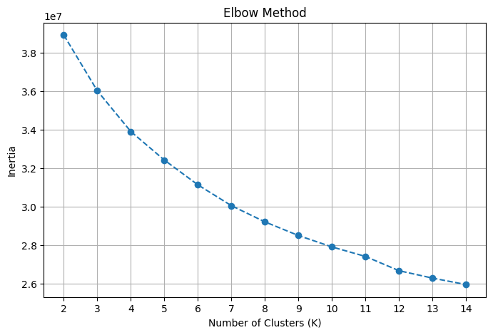

```python
# Investigate the change in within-cluster distance across number of clusters.
# HINT: Use matplotlib's plot function to visualize this relationship.

plt.figure(figsize=(8,5))
plt.plot(K_range, inertia, marker='o', linestyle='--')
plt.xlabel("Number of Clusters (K)")
plt.ylabel("Inertia")
plt.title("Elbow Method")
plt.xticks(range(2,15))
plt.grid()
plt.savefig("images/elbow_curve.png", bbox_inches="tight")
plt.show()
```

```python
# Check silhouette score

sample_size = 10000
indices = np.random.choice(len(X_pca), sample_size, replace=False)
X_sample = X_pca[indices]

for k in range(2,10):
    kmeans = KMeans(n_clusters=k, random_state=42, n_init=10)
    labels = kmeans.fit_predict(X_sample)
    score = silhouette_score(X_sample, labels)
    print(f"K = {k}, Silhouette Score = {score:.4f}")
```

```
K = 2, Silhouette Score = 0.1549
K = 3, Silhouette Score = 0.1236
K = 4, Silhouette Score = 0.1102
K = 5, Silhouette Score = 0.1012
K = 6, Silhouette Score = 0.1038
K = 7, Silhouette Score = 0.1082
K = 8, Silhouette Score = 0.1065
K = 9, Silhouette Score = 0.1022
```

```python
# Re-fit the k-means model with the selected number of clusters and obtain
# cluster predictions for the general population demographics data.

kmeans = KMeans(n_clusters=4, random_state=42, n_init=10)
cluster_labels = kmeans.fit_predict(X_pca)
```

### Discussion 3.1: Apply Clustering to General Population

Silhouette scores are highest at K=2, but this represents an overly coarse segmentation. As K increases, the scores gradually decrease and stabilize, indicating that while cluster separation weakens slightly, additional clusters still capture meaningful structure.

Considering both the elbow plot and silhouette scores, K=4 was selected as the optimal number of clusters. This choice provides a good balance between capturing meaningful variation in the data and maintaining interpretability of the resulting segments.

### Step 3.2: Apply All Steps to the Customer Data

Now that you have clusters and cluster centers for the general population, it's time to see how the customer data maps on to those clusters. Take care to not confuse this for re-fitting all of the models to the customer data. Instead, you're going to use the fits from the general population to clean, transform, and cluster the customer data. In the last step of the project, you will interpret how the general population fits apply to the customer data.

- Don't forget when loading in the customers data, that it is semicolon (`;`) delimited.
- Apply the same feature wrangling, selection, and engineering steps to the customer demographics using the `clean_data()` function you created earlier. (You can assume that the customer demographics data has similar meaning behind missing data patterns as the general demographics data.)
- Use the sklearn objects from the general demographics data, and apply their transformations to the customers data. That is, you should not be using a `.fit()` or `.fit_transform()` method to re-fit the old objects, nor should you be creating new sklearn objects! Carry the data through the feature scaling, PCA, and clustering steps, obtaining cluster assignments for all of the data in the customer demographics data.

The preprocessing and modeling steps developed using the general population dataset are now applied to the customer dataset.

The same cleaning and feature engineering steps are applied using the `clean_data()` function. The previously fitted imputer, scaler, PCA model, and KMeans model are then used to transform and assign clusters to the customer data without refitting.

```python
# Load in the customer demographics data.
df_customers = pd.read_csv(
    "Udacity_CUSTOMERS_Subset.csv",
    sep = ";",
    header = 0
)
```

```python
# Apply preprocessing, feature transformation, and clustering from the general
# demographics onto the customer data, obtaining cluster predictions for the
# customer demographics data.

df_customers = clean_data(df_customers)
set(df_demographics.columns) - set(df_customers.columns)
```

```
set()
```

```python
# Impute and scale
train_columns = df_demographics.columns

# The customer dataset was aligned to match the feature structure of the training dataset to ensure compatibility with
# the previously fitted imputer, scaler, and PCA models.
df_customers = df_customers.reindex(columns = train_columns, fill_value = np.nan)

df_customers_imputed = pd.DataFrame(
    imputer.transform(df_customers),
    columns=train_columns,
    index = df_customers.index
)

X_customers_scaled = scaler.transform(df_customers_imputed)
```

```python
X_customers_pca = pca.transform(X_customers_scaled)
```

```python
customer_clusters = kmeans.predict(X_customers_pca)
```

The customer dataset was processed using the same preprocessing pipeline as the general population dataset to ensure consistency.

The previously fitted imputer, scaler, PCA model, and clustering model were reused without refitting. This ensures that customer data is mapped into the same feature space and cluster structure defined by the general population.

This allows for a meaningful comparison between customer distribution and the overall population distribution across clusters.

### Step 3.3: Compare Customer Data to Demographics Data

At this point, you have clustered data based on demographics of the general population of Germany, and seen how the customer data for a mail-order sales company maps onto those demographic clusters. In this final substep, you will compare the two cluster distributions to see where the strongest customer base for the company is.

Consider the proportion of persons in each cluster for the general population, and the proportions for the customers. If we think the company's customer base to be universal, then the cluster assignment proportions should be fairly similar between the two. If there are only particular segments of the population that are interested in the company's products, then we should see a mismatch from one to the other. If there is a higher proportion of persons in a cluster for the customer data compared to the general population (e.g. 5% of persons are assigned to a cluster for the general population, but 15% of the customer data is closest to that cluster's centroid) then that suggests the people in that cluster to be a target audience for the company. On the other hand, the proportion of the data in a cluster being larger in the general population than the customer data (e.g. only 2% of customers closest to a population centroid that captures 6% of the data) suggests that group of persons to be outside of the target demographics.

Take a look at the following points in this step:

- Compute the proportion of data points in each cluster for the general population and the customer data. Visualizations will be useful here: both for the individual dataset proportions, but also to visualize the ratios in cluster representation between groups. Seaborn's [`countplot()`](https://seaborn.pydata.org/generated/seaborn.countplot.html) or [`barplot()`](https://seaborn.pydata.org/generated/seaborn.barplot.html) function could be handy.
  - Recall the analysis you performed in step 1.1.3 of the project, where you separated out certain data points from the dataset if they had more than a specified threshold of missing values. If you found that this group was qualitatively different from the main bulk of the data, you should treat this as an additional data cluster in this analysis. Make sure that you account for the number of data points in this subset, for both the general population and customer datasets, when making your computations!
- Which cluster or clusters are overrepresented in the customer dataset compared to the general population? Select at least one such cluster and infer what kind of people might be represented by that cluster. Use the principal component interpretations from step 2.3 or look at additional components to help you make this inference. Alternatively, you can use the `.inverse_transform()` method of the PCA and StandardScaler objects to transform centroids back to the original data space and interpret the retrieved values directly.
- Perform a similar investigation for the underrepresented clusters. Which cluster or clusters are underrepresented in the customer dataset compared to the general population, and what kinds of people are typified by these clusters?

The distribution of clusters in the general population is compared with the distribution in the customer dataset to identify which segments are overrepresented or underrepresented.

Clusters with higher representation in the customer dataset indicate likely target segments, while underrepresented clusters suggest segments less interested in the company’s offerings.

```python
# Compare the proportion of data in each cluster for the customer data to the
# proportion of data in each cluster for the general population.

pop_counts = pd.Series(cluster_labels).value_counts(normalize=True)
cust_counts = pd.Series(customer_clusters).value_counts(normalize=True)

comparison = pd.DataFrame({
    "Population": pop_counts,
    "Customers": cust_counts
})

comparison = comparison.fillna(0)

comparison["Difference"] = comparison["Customers"] - comparison["Population"]

comparison = comparison.sort_values("Difference", ascending=False)

comparison
```

|  | Population | Customers | Difference |
| --- | --- | --- | --- |
| 1 | 0.328632 | 0.525327 | 0.196695 |
| 3 | 0.215154 | 0.286107 | 0.070954 |
| 0 | 0.267172 | 0.172490 | -0.094682 |
| 2 | 0.189042 | 0.016076 | -0.172966 |

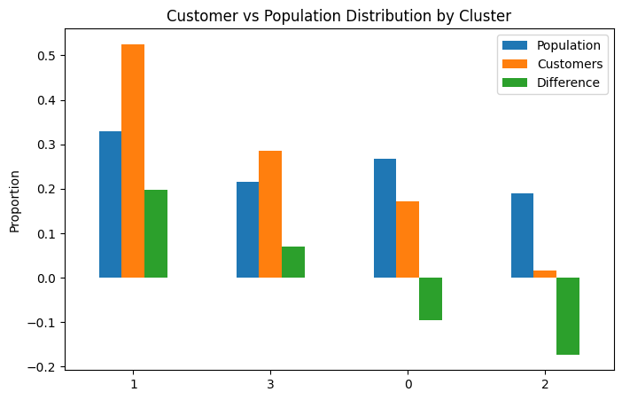

```python
comparison.plot(kind="bar", figsize=(8,5))
plt.title("Customer vs Population Distribution by Cluster")
plt.ylabel("Proportion")
plt.xticks(rotation=0)
plt.savefig("images/cust_vs_pop_dist.png", bbox_inches="tight")
plt.show()
```

Inspecting columns in these clusters

```python
# What kinds of people are part of a cluster that is overrepresented in the
# customer data compared to the general population

df_results = df_demographics.copy()
df_results["Cluster"] = cluster_labels

cluster_summary = df_results.groupby("Cluster").mean()

overall_mean = df_results.drop(columns=["Cluster"]).mean()

relative_summary = cluster_summary / overall_mean

for cluster_id in relative_summary.index:
    print(f"\nCluster {cluster_id} - Top Features")
    print(relative_summary.loc[cluster_id].sort_values(ascending=False).head(10))

    print(f"\nCluster {cluster_id} - Bottom Features")
    print(relative_summary.loc[cluster_id].sort_values().head(10))
```

```
Cluster 0 - Top Features
ANZ_HH_TITEL           2.126467
KBA05_ANTG4            1.930135
KBA05_ANTG3            1.793137
ANZ_HAUSHALTE_AKTIV    1.745486
PLZ8_ANTG4             1.650754
PLZ8_BAUMAX            1.434887
PLZ8_ANTG3             1.426109
CAMEO_INTL_WEALTH      1.306856
CAMEO_WEALTH           1.297946
FINANZ_HAUSBAUER       1.269041
Name: 0, dtype: Float64

Cluster 0 - Bottom Features
KBA05_ANTG1              0.298485
GREEN_AVANTGARDE         0.388442
YOUTH_MOVEMENT           0.388529
MOBI_REGIO               0.628487
ONLINE_AFFINITAET        0.635202
FINANZ_UNAUFFAELLIGER    0.664608
SEMIO_TRADV              0.696404
SEMIO_REL                0.702404
KBA05_GBZ                0.704394
FINANZ_ANLEGER           0.704788
Name: 0, dtype: Float64

Cluster 1 - Top Features
GREEN_AVANTGARDE       1.831356
YOUTH_MOVEMENT           1.7853
KBA05_ANTG1            1.753814
FINANZ_MINIMALIST      1.410647
MOBI_REGIO             1.400098
LP_LEBENSPHASE_FEIN    1.363116
ANZ_TITEL               1.35741
LP_LEBENSPHASE_GROB    1.319793
KBA05_GBZ              1.306315
PLZ8_ANTG1             1.287962
Name: 1, dtype: Float64

Cluster 1 - Bottom Features
```

[output cut: 48 more lines]

```
SEMIO_RAT                1.305735
Name: 3, dtype: Float64

Cluster 3 - Bottom Features
KBA05_ANTG4             0.149628
ANZ_HH_TITEL            0.237604
PLZ8_ANTG4              0.393545
ANZ_HAUSHALTE_AKTIV      0.40443
KBA05_ANTG3             0.448971
PLZ8_BAUMAX             0.558267
ANZ_TITEL               0.631691
PLZ8_ANTG3              0.633491
ALTERSKATEGORIE_GROB    0.663624
FINANZ_VORSORGER        0.673306
Name: 3, dtype: Float64
```

### Discussion 3.3: Compare Customer Data to Demographics Data

The comparison between customer and population cluster distributions reveals distinct differences in representation across segments.

**Overrepresented Clusters:**

**Underrepresented Clusters:**

**Overall Insight:**

This suggests that the company’s offerings are more appealing to value-conscious consumers and those who are actively engaged online, rather than affluent households. This insight can inform targeted marketing strategies and product positioning to either deepen engagement with current segments or better attract underrepresented affluent groups.

> Congratulations on making it this far in the project! Before you finish, make sure to check through the entire notebook from top to bottom to make sure that your analysis follows a logical flow and all of your findings are documented in **Discussion** cells. Once you've checked over all of your work, you should export the notebook as an HTML document to submit for evaluation. You can do this from the menu, navigating to **File -> Download as -> HTML (.html)**. You will submit both that document and this notebook for your project submission.